# Project: Research About Health Data in Gapminder Database

- Introduction
- Question 1
- Question 2
- Question 3
- Data Wrangling
- General Properties
- Data Types
- Data Description
- Imports
- Loading the Data
- Merging the Data
- Adding New Columns
- Clening the Data
- Exploratory Data Analysis
- Research Question 1
- Research Question 2
- Research Question 3
- Conclusions
- Conclusion 1
- Conclusion 2
- Conclusion 3

## Introduction

In this project we have analized some of the data collected on the web site http://www.gapminder.org/data/. On this page we can find a lot of information referred to many countries (economical, social, geographical, etc), but we have focused in some data related with health. Expecifically, we have estudied the data related with health expenditures (public and private), life expectancy, and the data gathered about some cancer types.

The total number of countries with data collected are 197.

### Question 1: What Is The Influence Of The Ratio Private/Total Health Expenditure In The Life Expectancy And In The Cancer Treatments Success?

Some countries have a strong public health system and the investment in health care comes mainly from the goverment, while others confide more in private institutions to solve the health issues. We would like to compare both cases, analyzing the percentage of private investments in each country and comparing them with the life expectancy and the rate of deaths by cancer causes for each country. The analisys was made for 2010.

### Question 2: Compare The Increment In Total Health Spending Between 1995 and 2010 With The Increment In The Life Expectancy And Healing Cancer Ratios During These Years.

We are also interested in knowing how the total investments in health have grown in the last years. In which regions of the world have increased more and in which have increased less. We want also to compare this values with the increment of the life expectancy and the percentage of deaths by cancer. Which regions have had a better behaviour?

We would also like to know how much is the mean increment in the total health spending for one year of increment in the life expectancy. This value will be calculated depending on the life expectancy. I mean, It is not the same to increase one year if the life expectancy is 60 than if the life expectancy is 70.

This increments were avaluated for the years 1995 and 2010.

### Question 3: Relation Between The Cancer Types And The Region Of The World Or The Human Development Index (HDI).

In this part we have studied the correlation between the types of cancer, the region of the world and the HDI, if there is any. We want to know which cancer type causes more deaths in each region of the world.

The regions will be evaluated by geographical areas, but we will make also the research dividing the countries by HDI (Human Development Index). We are also interested in knowing how is the behaviour in coutries with less development and compare them with those with a higher index. Are some types of cancer more usual in coutries with hight HDI?, whereas, which ones are more frequent in contries with low development?

We have analized this data for two years, 1995 and 2015, to observe any difference.

## Data Wrangling

### Data Types:

All the loaded dataframes have the seme structure:

- The **country** is used as index for rows and each **year** represents a column in the dataframe.
- **year and country**, are both as strings.
- The **values** are all **float64**.
- The meaning of the data is indicated in the name of the file or the dataframe.

### Data Description:

This is the description of the values according to the **gapminder** page.

- **year:** The year in which the values were taken.
- **country:** The country for each value.
- **hdi:** Human development index. Is an index used to rank the countries by level of 'human development'. It contains three dimnensions: health level, educational level, and living standard.
- **life_expectancy:** The average number of years a newborn child would live if current mortality patterns were to stay the same.
- **gov_health_spend:** The average health expenditure per person that has been paid by gobernment entities, expressed in US dollars using the exchange rate.
- **total_health_spend:** The average health expenditure per person, expressed in US dollars using the average exchange rate.
- **private_health_spend:** Private share of health expenditure (%). Percentage of total health expenditure that has been paid by private entities, for exampel commercial insurance and out-of-pocket payments.
- **breast_cancer_deaths_w, cervical_cancer_deaths_w, colonandrectum_cancer_deaths_w, liver_cancer_deaths_w, lung_cancer_deaths_w, stomach_cancer_deaths_w, colonandrectum_cancer_deaths_m, liver_cancer_deaths_m, lung_cancer_deaths_m, prostate_cancer_deaths_m, stomach_cancer_deaths_m:** Number of deaths due to each type of cancer in 100,000 male or female residents during the certain year. This rate is calculated as if each country has the same age composition as the world population.
- **breast_cancer_new_cases_w, cervical_cancer_new_cases_w, colonandrectum_cancer_new_cases_w, liver_cancer_new_cases_w, lung_cancer_new_cases_w, stomach_cancer_new_cases_w, colonandrectum_cancer_new_cases_m, liver_cancer_new_cases_m, lung_cancer_new_cases_m, prostate_cancer_new_cases_m, stomach_cancer_new_cases_m:** Number new cases due to each type of cancer in 100,000 male or female residents during the certain year. This rate is calculated as if each country has the same age composition as the world population.

**df_regions** description: This dataframe is a little different:

- The **country** column acts as the index of the dataframe. It has also four more columns dividing the countries in regions:
- **four_regions:** ['africa', 'americas', 'asia', 'europe']
- **six_regions:** ['middle_east_north_africa', 'sub_saharan_africa', 'america',

  ```
   'south_asia', 'europe_central_asia', 'east_asia_pacific']
  ```

- **eight_regions:** ['africa_north', 'africa_sub_saharan', 'america_north',

  ```
   'america_south', 'asia_west', 'east_asia_pacific', 'europe_east',
   'europe_west']
  ```

- **nine_regions:** ['africa_north', 'africa_sub_saharan', 'america_central',

  ```
   'america_north', 'america_south', 'asia_west', 'east_asia_pacific',
   'europe_east', 'europe_west']
  ```

All the datatypes are strings. In any case we only have used the **nine_regions** division.

### Imports

```python
# Imports:

import numpy as np
import pandas as pd
import seaborn as sns
import matplotlib.pyplot as plt
from functools import reduce


%matplotlib inline
plt.style.use('seaborn-deep')
```

### Loading The Data

- We load all the neccesary files in a set of dataframes.

```python
# Load all the necessary data in one global dataframe.

#dataframe with human development index.
df_hdi = pd.read_csv('hdi_human_development_index.csv')

#These changes will be explained later.
df_hdi = df_hdi.fillna(method='bfill',axis =1)
df_hdi = df_hdi.fillna(method='ffill',axis =1)

#dataframe with life expectancy.
df_life_expectancy = pd.read_csv('life_expectancy_years.csv')

#dataframes with health costs per person in us dollars. Goverment investment and total.
df_gov_health_spend = pd.read_csv('government_health_spending_per_person_us.csv')
df_total_health_spend = pd.read_csv('total_health_spending_per_person_us.csv')

#These changes will be explained later.
df_total_health_spend = df_total_health_spend.fillna(method='bfill',axis =1)
df_total_health_spend = df_total_health_spend.fillna(method='ffill',axis =1)
df_gov_health_spend = df_gov_health_spend.fillna(method='bfill',axis =1)
df_gov_health_spend = df_gov_health_spend.fillna(method='ffill',axis =1)

#The percent value of the private health spending over total spending.
df_private_health_spend_pc = pd.read_csv('private_share_of_total_health_spending_percent.csv')

df_private_health_spend_pc = df_private_health_spend_pc.fillna(method='bfill',axis =1)
df_private_health_spend_pc = df_private_health_spend_pc.fillna(method='ffill',axis =1)

#data frames with number of deaths by 100K people for different cancer types.
df_breast_cancer_deaths_w = pd.read_csv('breast_cancer_deaths_per_100000_women.csv')
df_cervical_cancer_deaths_w = pd.read_csv('cervical_cancer_deaths_per_100000_women.csv')
df_colonandrectum_cancer_deaths_w = pd.read_csv('colonandrectum_cancer_deaths_per_100000_women.csv')
df_liver_cancer_deaths_w = pd.read_csv('liver_cancer_deaths_per_100000_women.csv')
df_lung_cancer_deaths_w = pd.read_csv('lung_cancer_deaths_per_100000_women.csv')
df_stomach_cancer_deaths_w = pd.read_csv('stomach_cancer_deaths_per_100000_women.csv')
df_colonandrectum_cancer_deaths_m = pd.read_csv('colonandrectum_cancer_deaths_per_100000_men.csv')
df_liver_cancer_deaths_m = pd.read_csv('liver_cancer_deaths_per_100000_men.csv')
df_lung_cancer_deaths_m = pd.read_csv('lung_cancer_deaths_per_100000_men.csv')
df_prostate_cancer_deaths_m = pd.read_csv('prostate_cancer_deaths_per_100000_men.csv')
df_stomach_cancer_deaths_m = pd.read_csv('stomach_cancer_deaths_per_100000_men.csv')

#data frames with number of cancer cases by 100K people for different cancer types.
df_breast_cancer_new_cases_w = pd.read_csv('breast_cancer_new_cases_per_100000_women.csv')
df_cervical_cancer_new_cases_w = pd.read_csv('cervical_cancer_new_cases_per_100000_women.csv')
df_colonandrectum_cancer_new_cases_w = pd.read_csv('colonandrectum_cancer_new_cases_per_100000_women.csv')
df_liver_cancer_new_cases_w = pd.read_csv('liver_cancer_new_cases_per_100000_women.csv')
df_lung_cancer_new_cases_w = pd.read_csv('lung_cancer_new_cases_per_100000_women.csv')
df_stomach_cancer_new_cases_w = pd.read_csv('stomach_cancer_new_cases_per_100000_women.csv')
df_colonandrectum_cancer_new_cases_m = pd.read_csv('colonandrectum_cancer_new_cases_per_100000_men.csv')
df_liver_cancer_new_cases_m = pd.read_csv('liver_cancer_new_cases_per_100000_men.csv')
df_lung_cancer_new_cases_m = pd.read_csv('lung_cancer_new_cases_per_100000_men.csv')
df_prostate_cancer_new_cases_m = pd.read_csv('prostate_cancer_new_cases_per_100000_men.csv')
df_stomach_cancer_new_casess_m = pd.read_csv('stomach_cancer_new_cases_per_100000_men.csv')

#It creates a dataframe for grouping the countries in differente regions.
df_regions = pd.read_csv('regions.csv')
```

### Merging The Data

- In this part all the dataframes will be merged in a sigle dataframe called **df_global**. We use a dictionary to make it more easy and to use the key to name the columns in the new dataframe.

```python
#It creates dictionary of dataframes. The keys will be used to name the columns in the global datafrme.

dfs = {'hdi': df_hdi,
       'life_expectancy': df_life_expectancy,
       'gov_health_spend': df_gov_health_spend,
       'total_health_spend': df_total_health_spend,
       'private_health_spend_pc': df_private_health_spend_pc,
       'breast_cancer_deaths_w': df_breast_cancer_deaths_w,
       'cervical_cancer_deaths_w': df_cervical_cancer_deaths_w,
       'colonandrectum_cancer_deaths_w': df_colonandrectum_cancer_deaths_w,
       'liver_cancer_deaths_w': df_liver_cancer_deaths_w,
       'lung_cancer_deaths_w': df_lung_cancer_deaths_w,
       'stomach_cancer_deaths_w': df_stomach_cancer_deaths_w,
       'colonandrectum_cancer_deaths_m': df_colonandrectum_cancer_deaths_m,
       'liver_cancer_deaths_m': df_liver_cancer_deaths_m,
       'lung_cancer_deaths_m': df_lung_cancer_deaths_m,
       'prostate_cancer_deaths_m': df_prostate_cancer_deaths_m,
       'stomach_cancer_deaths_m': df_stomach_cancer_deaths_m,
       'breast_cancer_new_cases_w': df_breast_cancer_new_cases_w,
       'cervical_cancer_new_cases_w': df_cervical_cancer_new_cases_w,
       'colonandrectum_cancer_new_cases_w': df_colonandrectum_cancer_new_cases_w,
       'liver_cancer_new_cases_w': df_liver_cancer_new_cases_w,
       'lung_cancer_new_cases_w': df_lung_cancer_new_cases_w,
       'stomach_cancer_new_cases_w': df_stomach_cancer_new_cases_w,
       'colonandrectum_cancer_new_cases_m': df_colonandrectum_cancer_new_cases_m,
       'liver_cancer_new_cases_m': df_liver_cancer_new_cases_m,
       'lung_cancer_new_cases_m': df_lung_cancer_new_cases_m,
       'prostate_cancer_new_cases_m': df_prostate_cancer_new_cases_m,
       'stomach_cancer_new_cases_m': df_stomach_cancer_deaths_m,
      }

#It changes the structure of the original dataframes.
#We create a list of dataframe, each one with the columns 'country', 'year' and 'value'.

dfs1 = [dfs[key].melt(id_vars=["country"], var_name = "year", value_name = key) for key in dfs]

#It performs a merge of all the data frames included in the previous list.

df_global = reduce(lambda left,right: pd.merge(left,right,on=['country', 'year'],
                                               how='outer'), dfs1).sort_values(by=['country', 'year'])

#It performs a separeted merge with the dataframe regions. That is because regions doesn't have the column year.
#The countries are grouped in differente regions.

df_global = df_global.merge(df_regions, left_on=['country'], right_on=['country'], how='outer')
```

### Adding New Columns

- It adds some additional columns calculated from the original data. For example we calculate the private health expenditure per person in US dollars using the percent value in **private_health_spend_pc** column. It also adds columns with the **totals of cancer deaths and cases**, summing the corresponding columns.

```python
#It calculates the value of total dollars spended in private health for 100K habitants
#using the percentage value 'private_health_spend_pc'

df_global['private_health_spend'] = round(df_global['private_health_spend_pc'] * df_global['total_health_spend'] / 100, 2)

#It adds a column with the total cancer deaths for men.

cancer_men_list_death = ['colonandrectum_cancer_deaths_m',
                         'liver_cancer_deaths_m',
                         'lung_cancer_deaths_m',
                         'prostate_cancer_deaths_m',
                         'stomach_cancer_deaths_m']

df_global['total_cancer_men_death'] = df_global[cancer_men_list_death].sum(axis=1)

#It adds a column with the total cancer deaths for women.

cancer_women_list_death = ['breast_cancer_deaths_w',
                           'cervical_cancer_deaths_w',
                           'colonandrectum_cancer_deaths_w',
                           'liver_cancer_deaths_w',
                           'lung_cancer_deaths_w',
                           'stomach_cancer_deaths_w']

df_global['total_cancer_women_death'] = df_global[cancer_women_list_death].sum(axis=1)

#It adds a column with the total cancer cases for men.

cancer_men_list_cases = ['colonandrectum_cancer_new_cases_m',
                         'liver_cancer_new_cases_m',
                         'lung_cancer_new_cases_m',
                         'prostate_cancer_new_cases_m',
                         'stomach_cancer_new_cases_m']

df_global['total_cancer_men_cases'] = df_global[cancer_men_list_cases].sum(axis=1)

#It adds a column with the total cancer cases for women.

cancer_women_list_cases = ['breast_cancer_new_cases_w',
                           'cervical_cancer_new_cases_w',
                           'colonandrectum_cancer_new_cases_w',
                           'liver_cancer_new_cases_w',
                           'lung_cancer_new_cases_w',
                           'stomach_cancer_new_cases_w']

df_global['total_cancer_women_cases'] = df_global[cancer_women_list_cases].sum(axis=1)

#It sums both cases for women and men.

df_global['total_cancer_cases'] = df_global['total_cancer_women_cases'] + df_global['total_cancer_men_cases']
df_global['total_cancer_death'] = df_global['total_cancer_women_death'] + df_global['total_cancer_men_death']

#It calculates year by year the difference and percentage betwen total new cases and deaths. It gives us an estimation of the
#treatments against cancer success.

df_global['total_cancer_heal'] = df_global['total_cancer_cases'] - df_global['total_cancer_death']
df_global['total_cancer_heal_pc'] = round((df_global['total_cancer_cases'] - df_global['total_cancer_death'])
                                          / df_global['total_cancer_cases'] * 100, 2)
```

```python
df_global.info()
```

```
<class 'pandas.core.frame.DataFrame'>
Int64Index: 41098 entries, 0 to 41097
Data columns (total 42 columns):
country                              41098 non-null object
year                                 41095 non-null object
hdi                                  4862 non-null float64
life_expectancy                      40437 non-null float64
gov_health_spend                     3040 non-null float64
total_health_spend                   3008 non-null float64
private_health_spend_pc              3040 non-null float64
breast_cancer_deaths_w               6729 non-null float64
cervical_cancer_deaths_w             6722 non-null float64
colonandrectum_cancer_deaths_w       6189 non-null float64
liver_cancer_deaths_w                5493 non-null float64
lung_cancer_deaths_w                 6698 non-null float64
stomach_cancer_deaths_w              6686 non-null float64
colonandrectum_cancer_deaths_m       6204 non-null float64
liver_cancer_deaths_m                5488 non-null float64
lung_cancer_deaths_m                 6713 non-null float64
prostate_cancer_deaths_m             6724 non-null float64
stomach_cancer_deaths_m              6657 non-null float64
breast_cancer_new_cases_w            5326 non-null float64
cervical_cancer_new_cases_w          5326 non-null float64
colonandrectum_cancer_new_cases_w    5326 non-null float64
liver_cancer_new_cases_w             5322 non-null float64
lung_cancer_new_cases_w              5326 non-null float64
stomach_cancer_new_cases_w           5326 non-null float64
colonandrectum_cancer_new_cases_m    5326 non-null float64
liver_cancer_new_cases_m             5325 non-null float64
lung_cancer_new_cases_m              5326 non-null float64
prostate_cancer_new_cases_m          5326 non-null float64
stomach_cancer_new_cases_m           6657 non-null float64
four_regions                         41098 non-null object
eight_regions                        41098 non-null object
six_regions                          41098 non-null object
nine_regions                         41098 non-null object
private_health_spend                 3008 non-null float64
total_cancer_men_death               41098 non-null float64
total_cancer_women_death             41098 non-null float64
total_cancer_men_cases               41098 non-null float64
total_cancer_women_cases             41098 non-null float64
total_cancer_cases                   41098 non-null float64
total_cancer_death                   41098 non-null float64
total_cancer_heal                    41098 non-null float64
total_cancer_heal_pc                 6859 non-null float64
dtypes: float64(36), object(6)
memory usage: 13.5+ MB
```

- Total number of countrie analized:

```python
df_global.country.nunique()
```

```
197
```

### Data Cleaning: Preparing Subframes for Queries.

```python
# After discussing the structure of the data and any problems that need to be
#   cleaned, perform those cleaning steps in the second part of this section.
```

- We have create a new dataframe selecting some columns from **df_global** called **df_health1**. It will be used to investigate differences between countries regarding the relation between the public and private health investments in order to see their effects in the success of health caring.

```python
cols = ['year',
        'country',
        'nine_regions',
        'life_expectancy',
        'total_cancer_heal_pc',
        'total_health_spend',
        'gov_health_spend',
        'private_health_spend',
        'private_health_spend_pc']
df_health1 = df_global [cols]

(df_health1[df_health1.total_health_spend.notnull()].year.min(),
df_health1[df_health1.total_health_spend.notnull()].year.max())
```

```
('1995', '2010')
```

- The first year we have health spending data is 1995, and the last is 2010. So we are going to make analisys and comparissons between this two years.

  ```
  df_health1[(df_health_q1.year == '2010') & (df_health1.total_health_spend.isnull())].country.unique()

  array(['Bangladesh', 'Honduras', 'Liechtenstein', 'Mexico', 'Nepal',
   'Nicaragua', 'North Korea', 'Palestine', 'Somalia', 'South Sudan',
   'Zimbabwe'], dtype=object)

  df_health1[(df_health1.year == '1995') & (df_health1.total_health_spend.isnull())].country.unique()

  array(['Afghanistan', 'Bangladesh', 'Iraq', 'Liberia', 'Liechtenstein',
   'Nepal', 'North Korea', 'Palestine', 'South Sudan'], dtype=object)
  ```

  In a first analisys we saw that some countries didn't have some data in health spending on this years. I decided to extend the existing values back and forward for this countries. An specially important case is Mexico, because belongs to North America and this only has three countries. So the lack of Mexico can influence a lot in the total mean. The easiest way of doing a backfill and a forwardfill of this values is to do it in the first dataframe, when we charged the original file. It is for that tha this step is done above, after charging the data files. I have put here the result of the commands for countries with no total_health data in 2010 and 1995 to see the result without doing the filling.

```python
df_health1[(df_health1.year == '2010') & (df_health1.total_health_spend.isnull())].country.unique()
```

```
array(['Bangladesh', 'Liechtenstein', 'Nepal', 'North Korea', 'Palestine',
       'South Sudan'], dtype=object)
```

```python
df_health1[(df_health1.year == '1995') & (df_health1.total_health_spend.isnull())].country.unique()
```

```
array(['Bangladesh', 'Liechtenstein', 'Nepal', 'North Korea', 'Palestine',
       'South Sudan'], dtype=object)
```

- Anyway there is some countries that do not have any data. So we are going to delete this rows.

```python
df_health1 = df_health1.dropna(subset=['total_health_spend'])
df_health1.info()
```

```
<class 'pandas.core.frame.DataFrame'>
Int64Index: 3008 entries, 195 to 41086
Data columns (total 9 columns):
year                       3008 non-null object
country                    3008 non-null object
nine_regions               3008 non-null object
life_expectancy            2912 non-null float64
total_cancer_heal_pc       2912 non-null float64
total_health_spend         3008 non-null float64
gov_health_spend           3008 non-null float64
private_health_spend       3008 non-null float64
private_health_spend_pc    3008 non-null float64
dtypes: float64(6), object(3)
memory usage: 235.0+ KB
```

- We are only going to need the data for 1995 and 2010, so we can delete the other data.

```python
df_health1 = df_health1[df_health1.year.isin(['1995', '2010'])]
df_health1.info()
```

```
<class 'pandas.core.frame.DataFrame'>
Int64Index: 376 entries, 195 to 41086
Data columns (total 9 columns):
year                       376 non-null object
country                    376 non-null object
nine_regions               376 non-null object
life_expectancy            364 non-null float64
total_cancer_heal_pc       364 non-null float64
total_health_spend         376 non-null float64
gov_health_spend           376 non-null float64
private_health_spend       376 non-null float64
private_health_spend_pc    376 non-null float64
dtypes: float64(6), object(3)
memory usage: 29.4+ KB
```

```python
df_health1[df_health1.life_expectancy.isnull()].country.unique()
```

```
array(['Monaco', 'Nauru', 'Palau', 'San Marino', 'St. Kitts and Nevis',
       'Tuvalu'], dtype=object)
```

- There are some small countries with no Life Expectancy data, so we proceed also to delete this rows.

```python
df_health1 = df_health1.dropna(subset=['life_expectancy'])
df_health1.info()
```

```
<class 'pandas.core.frame.DataFrame'>
Int64Index: 364 entries, 195 to 41086
Data columns (total 9 columns):
year                       364 non-null object
country                    364 non-null object
nine_regions               364 non-null object
life_expectancy            364 non-null float64
total_cancer_heal_pc       364 non-null float64
total_health_spend         364 non-null float64
gov_health_spend           364 non-null float64
private_health_spend       364 non-null float64
private_health_spend_pc    364 non-null float64
dtypes: float64(6), object(3)
memory usage: 28.4+ KB
```

This data frame is clean now. All the column types are float except year country and nine_regions, which are strings, so it is not necessary to do changes in the data types.

- We define a different data frame including the columns **year, country, hdi, nine_regions and all the the columns related with cancer deaths**. In this case, we are going to use this dataframe to compare the data y 1995 with the data in 2015, so we only store the data for this two years.

```python
cols = ['year',  'country', 'hdi', 'nine_regions']
cols = cols + cancer_men_list_death + cancer_women_list_death + ['total_cancer_women_death', 'total_cancer_men_death']
df_health2 = df_global [cols]

df_health2 = df_global [cols]
df_health2 = df_health2.query('year in ["1995", "2015"]')
df_health2.info()
```

```
<class 'pandas.core.frame.DataFrame'>
Int64Index: 384 entries, 195 to 41091
Data columns (total 17 columns):
year                              384 non-null object
country                           384 non-null object
hdi                               374 non-null float64
nine_regions                      384 non-null object
colonandrectum_cancer_deaths_m    373 non-null float64
liver_cancer_deaths_m             373 non-null float64
lung_cancer_deaths_m              373 non-null float64
prostate_cancer_deaths_m          373 non-null float64
stomach_cancer_deaths_m           373 non-null float64
breast_cancer_deaths_w            373 non-null float64
cervical_cancer_deaths_w          373 non-null float64
colonandrectum_cancer_deaths_w    373 non-null float64
liver_cancer_deaths_w             373 non-null float64
lung_cancer_deaths_w              373 non-null float64
stomach_cancer_deaths_w           373 non-null float64
total_cancer_women_death          384 non-null float64
total_cancer_men_death            384 non-null float64
dtypes: float64(14), object(3)
memory usage: 54.0+ KB
```

```python
df_health2[(df_health2.year == '1995') & (df_health2.colonandrectum_cancer_deaths_m.isnull())].country.unique()
```

```
array(['Liechtenstein', 'Monaco', 'Nauru', 'Palau', 'Panama',
       'San Marino', 'St. Kitts and Nevis', 'Tuvalu'], dtype=object)
```

```python
df_health2[(df_health2.year == '2015') & (df_health2.colonandrectum_cancer_deaths_m.isnull())].country.unique()
```

```
array(['Liechtenstein', 'Palau', 'St. Kitts and Nevis'], dtype=object)
```

- There are a few rows with no data about cancer deaths. We are going in this case to delete them.

```python
df_health2 = df_health2.dropna(subset=['colonandrectum_cancer_deaths_m'])
df_health2.info()
```

```
<class 'pandas.core.frame.DataFrame'>
Int64Index: 373 entries, 195 to 41091
Data columns (total 17 columns):
year                              373 non-null object
country                           373 non-null object
hdi                               367 non-null float64
nine_regions                      373 non-null object
colonandrectum_cancer_deaths_m    373 non-null float64
liver_cancer_deaths_m             373 non-null float64
lung_cancer_deaths_m              373 non-null float64
prostate_cancer_deaths_m          373 non-null float64
stomach_cancer_deaths_m           373 non-null float64
breast_cancer_deaths_w            373 non-null float64
cervical_cancer_deaths_w          373 non-null float64
colonandrectum_cancer_deaths_w    373 non-null float64
liver_cancer_deaths_w             373 non-null float64
lung_cancer_deaths_w              373 non-null float64
stomach_cancer_deaths_w           373 non-null float64
total_cancer_women_death          373 non-null float64
total_cancer_men_death            373 non-null float64
dtypes: float64(14), object(3)
memory usage: 52.5+ KB
```

- There are also some rows without hdi. This index has been being calculated since not many years ago, and some countries had not been eavluated in 1995, but I think that this is not a data that it changes a lot with time, so we can do the same as we did with health spending data and make a backfill to take first value available for each country. I attach here the result of countries with no data in 1995 and 2015 before doing the backfill in the hdi.

  ```
    df_health2[(df_health2.year == '1995') & (df_health2.hdi.isnull())].country.unique()

    array(['Andorra', 'Angola', 'Antigua and Barbuda', 'Bahamas', 'Bhutan',
   'Bosnia and Herzegovina', 'Burkina Faso', 'Cape Verde', 'Chad',
   'Comoros', 'Dominica', 'Equatorial Guinea', 'Eritrea', 'Ethiopia',
   'Georgia', 'Grenada', 'Guinea-Bissau', 'Kiribati', 'Lebanon',
   'Liberia', 'Macedonia, FYR', 'Madagascar', 'Marshall Islands',
   'Micronesia, Fed. Sts.', 'Montenegro', 'Nigeria', 'North Korea',
   'Oman', 'Palestine', 'Seychelles', 'Solomon Islands', 'Somalia',
   'South Sudan', 'St. Lucia', 'St. Vincent and the Grenadines',
   'Suriname', 'Timor-Leste', 'Turkmenistan', 'Uzbekistan', 'Vanuatu'],
    dtype=object)
  ```

```
     df_health2[(df_health_q2.year == '2015') & (df_health2.hdi.isnull())].country.unique()

     array(['Marshall Islands', 'North Korea', 'Somalia'], dtype=object)
```

```python
df_health2[(df_health2.year == '1995') & (df_health2.hdi.isnull())].country.unique()
```

```
array(['Marshall Islands', 'North Korea', 'Somalia'], dtype=object)
```

```python
df_health2[(df_health2.year == '2015') & (df_health2.hdi.isnull())].country.unique()
```

```
array(['Marshall Islands', 'North Korea', 'Somalia'], dtype=object)
```

- Some countries don't have hdi data at all, even after doing the backfill. So we proceed to delete this rows.

```python
df_health2 = df_health2.dropna(subset=['hdi'])
df_health2.info()
```

```
<class 'pandas.core.frame.DataFrame'>
Int64Index: 367 entries, 195 to 41091
Data columns (total 17 columns):
year                              367 non-null object
country                           367 non-null object
hdi                               367 non-null float64
nine_regions                      367 non-null object
colonandrectum_cancer_deaths_m    367 non-null float64
liver_cancer_deaths_m             367 non-null float64
lung_cancer_deaths_m              367 non-null float64
prostate_cancer_deaths_m          367 non-null float64
stomach_cancer_deaths_m           367 non-null float64
breast_cancer_deaths_w            367 non-null float64
cervical_cancer_deaths_w          367 non-null float64
colonandrectum_cancer_deaths_w    367 non-null float64
liver_cancer_deaths_w             367 non-null float64
lung_cancer_deaths_w              367 non-null float64
stomach_cancer_deaths_w           367 non-null float64
total_cancer_women_death          367 non-null float64
total_cancer_men_death            367 non-null float64
dtypes: float64(14), object(3)
memory usage: 51.6+ KB
```

Finally this dataframe is also clean. As in the dataframe before we don't need to make any change in the data types.

- Now we need to reestructure the **df_health2** to define another query because we want to have all the cancer types in a sigle column. In the question 3 we want to show the correlation between the **hdi** and the different cancer causes in a matrix of graphs. To do that we need a categorical column with the type of cancer and another columns with the value, instead of one column for each type of cancer. This changes are loaded in a new dataframe called **df_health3**.

```python
df_health3 = df_health2.copy()
df_health3 = pd.melt(df_health3, id_vars=['year', 'country', 'hdi', 'nine_regions'],
                       value_vars=cancer_men_list_death + cancer_women_list_death +  ['total_cancer_women_death', 'total_cancer_men_death'],
                       var_name='cancer_type',
                       value_name='cancer_deaths')
df_health3['cancer_type'] = df_health3['cancer_type'].apply(lambda x: (x.split("_")[0]+' ' +x.split("_")[-1]).title())
df_health3.head()
```

|  | year | country | hdi | nine_regions | cancer_type | cancer_deaths |
| --- | --- | --- | --- | --- | --- | --- |
| 0 | 1995 | Afghanistan | 0.324 | asia_west | Colonandrectum M | 8.74 |
| 1 | 2015 | Afghanistan | 0.479 | asia_west | Colonandrectum M | 10.80 |
| 2 | 1995 | Albania | 0.628 | europe_east | Colonandrectum M | 7.48 |
| 3 | 2015 | Albania | 0.764 | europe_east | Colonandrectum M | 8.81 |
| 4 | 1995 | Algeria | 0.600 | africa_north | Colonandrectum M | 6.85 |

## Exploratory Data Analysis

- Before starting the analisys I would like to know how the life expectancy have growth in the last or two last centuries.

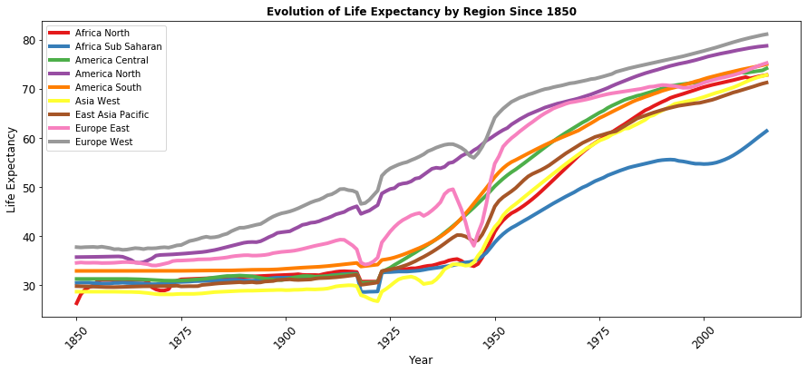

```python
#It makes a copy of df_global and group the values by regions (making the mean)
df_reg = df_global.groupby(['nine_regions','year'], as_index=False).mean()
#It filters for years between 1850 and 2015.
df_reg = df_reg[df_reg['year'].between('1850','2015')]
#Convert the year column from string to int so that the x-axis of the plot is arranged automatically.
df_reg['year'] = df_reg['year'].astype(int)
#It select the size and the colors of the plot.
plt.figure(figsize=(15,6))
palette = plt.get_cmap('Set1')
#It draws a line plot for each region. The x-axis is the year and the y-axis the medium average (5 years)
#of the mean life expectancy for each region.
for num, region in enumerate(df_reg['nine_regions'].unique()):
    plt.plot(df_reg[df_reg['nine_regions'] == region].year,
             df_reg[df_reg['nine_regions'] == region].life_expectancy.rolling(5, min_periods=1).mean(),
             color=palette(num),
             label = region.replace('_',' ').title(),
             linewidth = 4)
plt.legend(loc=2, prop={'size': 10})
plt.xlabel('Year', fontsize=12)
plt.title('Evolution of Life Expectancy by Region Since 1850', fontdict = {'fontsize': 12, 'fontweight': 'bold'})
plt.ylabel('Life Expectancy', fontsize=12)
plt.xticks( fontsize=12, rotation='45')
plt.xticks( fontsize=12, rotation='45')
plt.yticks(fontsize=12);
```

We can see in this picture that, since 1850, the life expectancy have experimented a great growth. We can easily apreciate the decrements during the two world wars period also. In the first case they must have been very relevant also the effects of the called 'spanish flu' or the 1929 Crash, because North America suffered also a big decrement in the life expectancy, and I don't think that the First World War were so relevent in the life expectancy of this region.

We have applied a moving average of 5 years.

### Research Question 1: What Is The Influence Of The Ratio Private/Total Health Expenditure In The Life Expectancy And In The Cancer Treatments Success?

- In this first question we are going to explore the differences between the public and private health investments. We are interested in knowing how relevant are they in reaching a high life expectancy and in the succeess of the treatments against cancer. Are more successful those countries with a higher public spending or those with a higher private health spending?

  To make this aproach we are going to start depicting a graph with the percentage of the private health spending over the total spending based in the years of life expectancy. In the x-axis we are going to divide the countries by life expectancy years in four quartiles. The first quartile represents the countries with smallest life expectancy and the last quartile corresponds with the countries with a highest number of years. We are going to use the dataframe **df_health1** filtered for the year 2010.

  The table and the graph with the results are showed below:

```python
#We make a copy of df_health1 filtered by year 2010
df1 = df_health1.copy()
df1 = df1.query('year == "2010"')
#It calculates 4 quartiles for the life expectancy.
df1['Life Expectancy Quartile'] = pd.qcut(df1.life_expectancy,
                                          4,
                                          labels=['First Quartile', 'Second Quartile', 'Third Quartile', 'Forth Quartile'])
#rename the columns so that the columns look better
df1.rename(columns=lambda x: x.strip().title().replace("_", " "), inplace=True)
#Group by quartiles
df1 = df1.groupby('Life Expectancy Quartile').mean().round(2)
df1[['Life Expectancy', 'Private Health Spend Pc']]
```

| Life Expectancy Quartile | Life Expectancy | Private Health Spend Pc |
| --- | --- | --- |
| First Quartile | 57.35 | 50.15 |
| Second Quartile | 68.91 | 45.59 |
| Third Quartile | 75.05 | 40.70 |
| Forth Quartile | 79.93 | 30.06 |

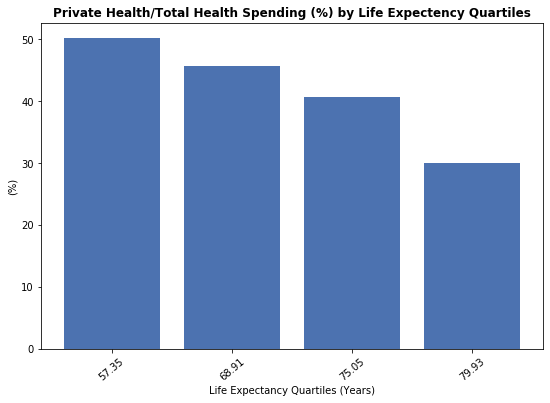

```python
#It draws the result in a bar plot.
plt.subplots(figsize=(9, 6))
plt.bar(df1.index, df1['Private Health Spend Pc'])
plt.title('Private Health/Total Health Spending (%) by Life Expectency Quartiles',
          fontdict = {'fontsize': 12, 'fontweight': 'bold'})
plt.xlabel('Life Expectancy Quartiles (Years)')
plt.ylabel('(%)')
plt.xticks(fontsize=10, rotation='40')
plt.xticks(np.arange(4), df1['Life Expectancy']);
```

We can see that the ratio is smaller for the countries with a higher life expectancy. In these countries, with almost 80 years of life expectancy, the private health represents the 30% of the total health spending, while in the first quartile represents the 50%

- As we said before, we are also interested in knowing how does the ratio between private/total(%) health investment influence in the ratio of deaths versus total the cases of cancer. To see this, we follow the same method as before. Dividing the countries in quartiles we are going to show which is the health investment ratio for the countries least and most successful in this issue. The calculations are made also for the year 2010.

```python
#We make a copy of df_health1 filtered by year 2010
df2 = df_health1.copy()
df2 = df2.query('year == "2010"')
#It calculates 4 quartiles for the Total Cancer Healing Percentage.
df2['Heal Percent Quartile'] = pd.qcut(df2.total_cancer_heal_pc,
                                       4,
                                       labels=['First Quartile', 'Second Quartile', 'Third Quartile', 'Forth Quartile'])
#rename the columns so that the columns look better
df2.rename(columns=lambda x: x.strip().title().replace("_", " "), inplace=True)
#Group by quartiles
df2 = df2.groupby('Heal Percent Quartile').mean().round(2)
df2[['Total Cancer Heal Pc', 'Private Health Spend Pc']]
```

| Heal Percent Quartile | Total Cancer Heal Pc | Private Health Spend Pc |
| --- | --- | --- |
| First Quartile | -8.65 | 49.86 |
| Second Quartile | 15.31 | 46.17 |
| Third Quartile | 30.41 | 39.57 |
| Forth Quartile | 52.32 | 30.88 |

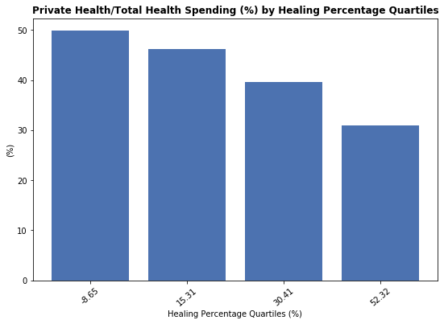

```python
#It draws the result in a bar plot.
plt.subplots(figsize=(9, 6))
plt.bar(df2.index, df2['Private Health Spend Pc'])
plt.title('Private Health/Total Health Spending (%) by Healing Percentage Quartiles',
          fontdict = {'fontsize': 12, 'fontweight': 'bold'})
plt.xlabel('Healing Percentage Quartiles (%)')
plt.ylabel('(%)')
plt.xticks(fontsize=10, rotation='40')
plt.xticks(np.arange(4), df2['Total Cancer Heal Pc']);
```

We can also see that the ratio private/total (%) is smaller in those countries with a higher percentage of healing success. The results are very similar to the previous case.

In the first quartile the healing percentage is negative. I don't know the reason because I don't know exactly the source of the data. In those countries the lack of means of detection of cancer probably can influence also in the data reported.

- Finally we are going to draw a comparative histogram to see the distribution of the countries over the ratio private/health spending(%). First we divide the countries in two goups: those that have a life expectancy greater than 75 years and those which life expectnacy is smaller. Then we depict both graphs grouping and counting all the countries in 10 bins according their rate private/total health expenditure(%).

```python
#We divide the dataframe df_health1 in two. One for life expectancy smaller than
#75 years and another for life expectancy bigger than that.
df4 = df_health1.query('life_expectancy < 75 & year == "2010"')
df3 = df_health1.query('life_expectancy >= 75 & year == "2010"')
#It renames the columns for looking better.
df3 = df3.rename(columns=lambda x: x.strip().title().replace("_", " "))
df4 = df4.rename(columns=lambda x: x.strip().title().replace("_", " "))
#Group the result by contry and calcs the mean.
df3 = df3.groupby('Country', as_index = False).mean().round(2)
df4 = df4.groupby('Country', as_index = False).mean().round(2)
```

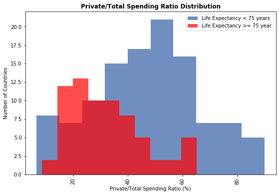

```python
#It draws two histograms in a graph. The value chosen to make the histogram is
#the ratio private/total health spending in percentage. The number of bins is 10.
plt.subplots(figsize=(9, 6))
plt.hist(df4['Private Health Spend Pc'], bins = 10, alpha = 0.8)
plt.hist(df3['Private Health Spend Pc'], bins = 10, color = 'r', alpha = 0.7)
plt.legend(['Life Expectancy < 75 years', 'Life Expectancy >= 75 year'])
plt.title('Private/Total Spending Ratio Distribution', fontdict = {'fontsize': 12, 'fontweight': 'bold'})
plt.xlabel('Private/Total Spending Ratio (%)')
plt.ylabel('Number of Countries')
plt.xticks(fontsize=10, rotation='vertical');
```

In this picture we can also see that those countries with life expectancy greater than 75 years tend to distribute in lower rates than those countries with smaller life expectnacy.

### Research Question 2: Compare The Increments In Total Health Spending Between 1995 and 2010 With The Increments In The Life Expectancy And Healing Cancer Ratios During These Years.

- This question is related to the previous one, but in this case we want to put the focus in the total health spending and its growth between 1995 and 2010 for each region. We also want to compare this increments with the achievements in terms of reaching a higher life expectancy and a cancer healing rates increments. The analisys will be made dividing the world in nine regions.

  Finally we will try to estimate how much it costs to increase a year in the life expectancy acording the current life expectancy. Or, which is the same, how much costs, in mean, to increase the life expectancy from 55 years to 56, from 65 to 66, 75 to 76, etc.

```python
#First we filter the dataframe df_health1 for 2010 and we group it by regions,
#calculating the mean for each region.
df_10 = df_health1.copy().query('year == "2010"')
df_10_regions = df_10.groupby('nine_regions').mean()
df_10.info()
```

```
<class 'pandas.core.frame.DataFrame'>
Int64Index: 182 entries, 210 to 41086
Data columns (total 9 columns):
year                       182 non-null object
country                    182 non-null object
nine_regions               182 non-null object
life_expectancy            182 non-null float64
total_cancer_heal_pc       182 non-null float64
total_health_spend         182 non-null float64
gov_health_spend           182 non-null float64
private_health_spend       182 non-null float64
private_health_spend_pc    182 non-null float64
dtypes: float64(6), object(3)
memory usage: 14.2+ KB
```

```python
#we do de same for 1995
df_95 = df_health1.copy().query('year == "1995"')
df_95_regions = df_95.groupby('nine_regions').mean()
df_95.info()
```

```
<class 'pandas.core.frame.DataFrame'>
Int64Index: 182 entries, 195 to 41071
Data columns (total 9 columns):
year                       182 non-null object
country                    182 non-null object
nine_regions               182 non-null object
life_expectancy            182 non-null float64
total_cancer_heal_pc       182 non-null float64
total_health_spend         182 non-null float64
gov_health_spend           182 non-null float64
private_health_spend       182 non-null float64
private_health_spend_pc    182 non-null float64
dtypes: float64(6), object(3)
memory usage: 14.2+ KB
```

```python
#we sustract the previous dataframes to see the increments by region
df_inc_regions = df_10_regions - df_95_regions
#We drop the columns that we don't need now.
df_inc_regions.drop(columns = ['gov_health_spend', 'private_health_spend', 'private_health_spend_pc'],inplace = True)
#Change the name of the columns.
df_inc_regions.rename(columns=lambda x: x.strip().title().replace("_", " "), inplace=True)
df_inc_regions.rename(index=lambda x: x.strip().title().replace("_", " "), inplace=True)
df_inc_regions.rename(columns = {'Life Expectancy': 'Life Expectancy Inc',
                       'Total Cancer Heal Pc': 'Total Cancer Heal Pc Inc',
                       'Total Health Spend': 'Total Health Spend Inc'}, inplace = True)
df_inc_regions.round(2)
```

| nine_regions | Life Expectancy Inc | Total Cancer Heal Pc Inc | Total Health Spend Inc |
| --- | --- | --- | --- |
| Africa North | 3.28 | 9.65 | 128.72 |
| Africa Sub Saharan | 4.37 | 0.44 | 77.29 |
| America Central | 1.13 | 5.27 | 304.46 |
| America North | 2.90 | 8.26 | 2786.00 |
| America South | 3.20 | 8.66 | 298.87 |
| Asia West | 4.50 | 8.61 | 266.18 |
| East Asia Pacific | 3.68 | 7.30 | 410.52 |
| Europe East | 4.28 | 9.06 | 567.35 |
| Europe West | 3.59 | 10.63 | 2342.71 |

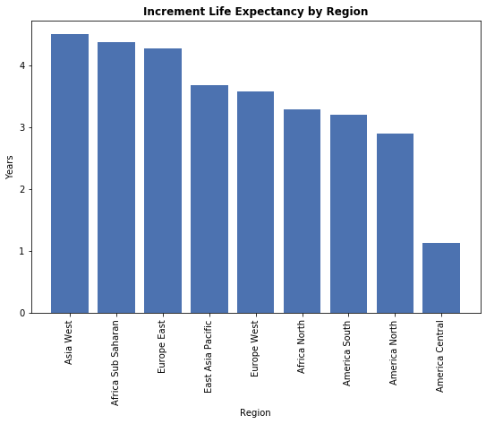

```python
#It draws a bar plot with the increment in the life expectancy by region.
df_inc_regions.sort_values('Life Expectancy Inc', inplace = True, ascending = False)
plt.subplots(figsize=(9, 6))
plt.bar(df_inc_regions.index, df_inc_regions['Life Expectancy Inc'])
plt.title('Increment Life Expectancy by Region', fontdict = {'fontsize': 12, 'fontweight': 'bold'})
plt.xlabel('Region')
plt.ylabel('Years')
plt.xticks(fontsize=10, rotation='vertical');
```

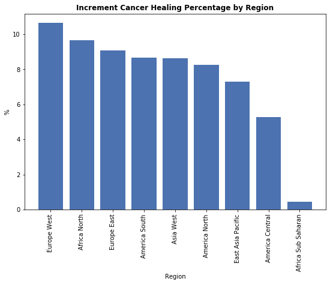

```python
#It draws a bar plot with the increment in the percentage of the cancer healing by region.
df_inc_regions.sort_values('Total Cancer Heal Pc Inc', inplace = True, ascending = False)
plt.subplots(figsize=(9, 6))
plt.bar(df_inc_regions.index, df_inc_regions['Total Cancer Heal Pc Inc'])
plt.title('Increment Cancer Healing Percentage by Region', fontdict = {'fontsize': 12, 'fontweight': 'bold'})
plt.xlabel('Region')
plt.ylabel('%')
plt.xticks(fontsize=10, rotation='vertical');
```

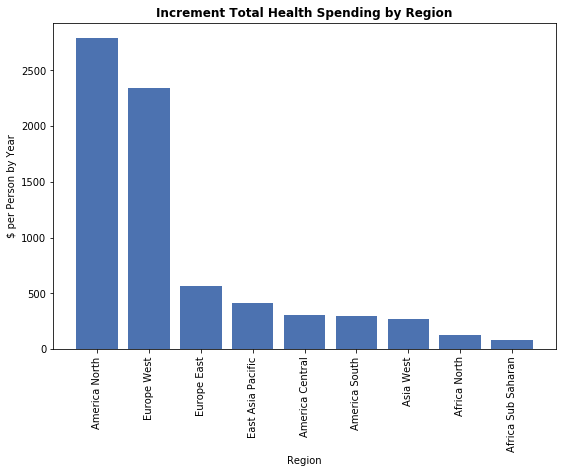

```python
#It draws a bar plot with the increment in the total health spending by region.
df_inc_regions.sort_values('Total Health Spend Inc', inplace = True, ascending = False)
plt.subplots(figsize=(9, 6))
plt.bar(df_inc_regions.index, df_inc_regions['Total Health Spend Inc'])
plt.title('Increment Total Health Spending by Region', fontdict = {'fontsize': 12, 'fontweight': 'bold'})
plt.xlabel('Region')
plt.ylabel('$ per Person by Year')
plt.xticks(fontsize=10, rotation='vertical');
```

But, in terms of health investments, North America and West Europe are by far the two regions which have increased more their spendings.

- Finally, we would like to estimate how much needs to increase its health investment a country in relation with its life expectancy. i.e. how much more expensive is to increase a year if its life expectancy is 75 than if its life expectancy is 55, for example.

```python
#rename the columns in both dataframes for both years before merging them.
df_10_mod = df_10.rename(columns=lambda x: x + "_2010")
df_95_mod = df_95.rename(columns=lambda x: x + "_1995")
```

```python
#It merges the dataframes for years 1995 and 2010.
df_combined = df_10_mod.merge(df_95_mod, left_on='country_2010', right_on='country_1995', how='inner')
#Adds new columns with the increment in the health spending and life expenctancy.
df_combined['total_health_spend_inc'] = df_combined['total_health_spend_2010'] - df_combined['total_health_spend_1995']
df_combined['life_expectancy_inc'] = df_combined['life_expectancy_2010'] - df_combined['life_expectancy_1995']
#We select the countries where life expectancy has grown
df_combined = df_combined[df_combined['life_expectancy_inc'] > 0]
#For each country we divide the increment in the health spending by de years of increment.
df_combined['total_health_spend_per_year'] = round(df_combined['total_health_spend_inc'] / df_combined['life_expectancy_inc'], 2)
#We make groups of 5 years in the life expectancy column.
df_combined['age_groups'] = (df_combined['life_expectancy_1995'] / 5).astype(int) * 5
#Rename all the columns to have a better view of the table.
df_combined.rename(columns=lambda x: x.strip().title().replace("_", " "), inplace=True)
#It calcs the mean for each group.
df_combined = df_combined.groupby('Age Groups').mean().round(2)
df_combined
```

| Age Groups | Life Expectancy 2010 | Total Cancer Heal Pc 2010 | Total Health Spend 2010 | Gov Health Spend 2010 | Private Health Spend 2010 | Private Health Spend Pc 2010 | Life Expectancy 1995 | Total Cancer Heal Pc 1995 | Total Health Spend 1995 | Gov Health Spend 1995 | Private Health Spend 1995 | Private Health Spend Pc 1995 | Total Health Spend Inc | Life Expectancy Inc | Total Health Spend Per Year |
| --- | --- | --- | --- | --- | --- | --- | --- | --- | --- | --- | --- | --- | --- | --- | --- |
| 40 | 64.60 | -8.36 | 55.50 | 27.80 | 27.69 | 49.90 | 44.60 | 13.75 | 10.30 | 3.77 | 6.54 | 63.50 | 45.20 | 20.00 | 2.26 |
| 45 | 55.90 | -0.17 | 128.51 | 87.49 | 41.13 | 54.73 | 47.71 | -0.29 | 14.68 | 5.33 | 9.34 | 61.88 | 113.83 | 8.19 | 10.23 |
| 50 | 58.12 | -7.06 | 42.18 | 18.52 | 23.69 | 60.24 | 52.29 | -5.83 | 16.51 | 5.96 | 10.56 | 61.51 | 25.67 | 5.84 | 4.16 |
| 55 | 61.54 | -7.23 | 107.99 | 67.61 | 40.34 | 48.59 | 57.74 | -7.35 | 37.32 | 19.40 | 17.92 | 53.77 | 70.66 | 3.80 | 64.42 |
| 60 | 67.35 | 8.71 | 138.41 | 82.30 | 56.16 | 44.49 | 62.70 | 6.29 | 41.75 | 28.41 | 13.34 | 42.55 | 96.66 | 4.64 | 38.94 |
| 65 | 72.02 | 22.72 | 331.26 | 210.32 | 120.90 | 39.77 | 67.94 | 14.87 | 72.12 | 42.03 | 30.11 | 45.76 | 259.14 | 4.08 | 79.30 |
| 70 | 75.76 | 31.17 | 638.21 | 417.44 | 220.77 | 38.14 | 72.37 | 19.79 | 247.48 | 158.00 | 89.45 | 39.71 | 390.73 | 3.40 | 125.24 |
| 75 | 80.58 | 53.66 | 3863.78 | 2828.66 | 1022.94 | 28.19 | 77.05 | 44.66 | 1744.75 | 1260.69 | 481.91 | 29.12 | 2119.03 | 3.53 | 611.57 |
| 80 | 82.70 | 62.74 | 3100.00 | 2170.00 | 926.90 | 29.90 | 80.30 | 53.30 | 1390.00 | 897.00 | 494.84 | 35.60 | 1710.00 | 2.40 | 712.50 |

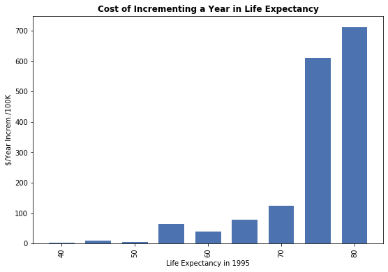

```python
#Draw the result in a bar plot. The x-axis represents groups of five years in the life expectancy.
#The y-axis represent how much it costs(the mean) to increase a year in the life expectancy for each group.
plt.subplots(figsize=(9, 6))
plt.bar(df_combined.index, df_combined['Total Health Spend Per Year'], width = 3.5)
plt.title('Cost of Incrementing a Year in Life Expectancy', fontdict = {'fontsize': 12, 'fontweight': 'bold'})
plt.xlabel('Life Expectancy in 1995')
plt.ylabel('$/Year Increm./100K')
plt.xticks(fontsize=10, rotation='vertical');
```

This graph shows that around 75 years the investments in health care of countries per incremented year are much bigger that for countries with lower life expectancy. This is expectable taking into account that these countries are closer to the limit and they are usually the richest ones.

### Research Question 3: Relation Between The Cancer Types And The Region Of The World Or The HDI (Human Development Index).

- In this part we are interested in knowing if there are some correlation between the HDI or the region of the world and the different cancer types.

  To analyze that we are going to investigate which is the most usual cause of cancer death in each region or in each group of HDI. The calculations will be made for 1995 and 2015. That will permit us to find out any difference between regions and see if there has been any change with time.

  We are going to start with the analysis by the Human Development Index (HDI). We separate the countries in quartiles again by the HDI. Then, it is calculated the mean of deaths in each quartile for each type of cancer. We select the causes with more deaths in each quartile and it is showed in a dataframe and in a bar plot. The analisys will be mado for both years.

```python
#Filter for year 1995. Group by quartiles of Human Development Index (hdi)
df5 = df_health2.query('year == "1995"')
df5 = df5.drop(columns = ['nine_regions'])
df5.hdi = pd.qcut(df5.hdi, 4, labels=['hdi25', 'hdi50', 'hdi75', 'hdi100'])
df5 = df5.groupby('hdi', as_index = False).mean().round(2)

#Filter for year 2015. Group by quartiles of Human Development Index (hdi)
df6 = df_health2.query('year == "2015"')
df6 = df6.drop(columns = ['nine_regions'])
df6.hdi = pd.qcut(df6.hdi, 4, labels=['hdi25', 'hdi50', 'hdi75', 'hdi100'])
df6 = df6.groupby('hdi', as_index = False).mean().round(2)
cols = cancer_men_list_death + cancer_women_list_death

#Get the cause of cancer with most deaths. Save the result for the two years in a single dataframe.
df5['max_deaths_1995'] = df5[cols].max(1)
df5['max_deaths_2015'] = df6[cols].max(1)
df5['max_cancer_case_1995'] = df5[cols].idxmax(1).str.title().str.replace("_", " ").str.replace('Deaths', '')
df5['max_cancer_case_2015'] = df6[cols].idxmax(1).str.title().str.replace("_", " ").str.replace('Deaths', '')
df5 = df5[['hdi', 'max_deaths_1995', 'max_cancer_case_1995', 'max_deaths_2015', 'max_cancer_case_2015']]
df5.rename(columns=lambda x: x.strip().title().replace("_", " "), inplace=True)
df5.set_index('Hdi')
```

| Hdi | Max Deaths 1995 | Max Cancer Case 1995 | Max Deaths 2015 | Max Cancer Case 2015 |
| --- | --- | --- | --- | --- |
| hdi25 | 28.12 | Cervical Cancer W | 32.24 | Prostate Cancer M |
| hdi50 | 28.99 | Lung Cancer M | 24.71 | Prostate Cancer M |
| hdi75 | 42.72 | Lung Cancer M | 33.34 | Lung Cancer M |
| hdi100 | 56.90 | Lung Cancer M | 43.44 | Lung Cancer M |

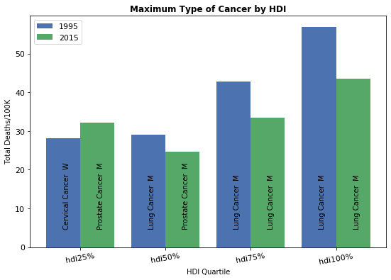

```python
#It draws the result in a bar plot.
#In the x-axis we set the four quarties of HDI
#In the y-axis we can see the mean of number of deaths for 100K people for the max cause of deaths.
#The results for the two years are showed in the same plot.
plt.subplots(figsize=(9, 6))
x = [0, 1, 2, 3]
x1 = [0.4, 1.4, 2.4, 3.4]
plt.bar(x, df5['Max Deaths 1995'], width=0.4)
plt.bar(x1, df5['Max Deaths 2015'], width=0.4)
plt.title('Maximum Type of Cancer by HDI', fontdict = {'fontsize': 12, 'fontweight': 'bold'})
plt.xlabel('HDI Quartile')
plt.ylabel('Total Deaths/100K')
plt.xticks(fontsize=11, rotation=10);
plt.yticks(fontsize=11)
#We add the name of the cause of cancer on each bar.
for i, v in enumerate(df5['Max Cancer Case 1995']):
    plt.text(i, 5, str(v), rotation=90, fontsize=10)
for i, v in enumerate(df5['Max Cancer Case 2015']):
    plt.text(i+0.4, 5, str(v), rotation=90, fontsize=10)
plt.xticks(np.arange(4)+0.2, ['hdi25%', 'hdi50%', 'hdi75%', 'hdi100%'])
plt.legend(['1995','2015'],loc=2, fontsize = 11);
```

We have found out some differences. In all the countries with high development index, the lung cancer in men seems to be the more usual and there has not been changes in the last years, except a decrement in the number of deaths by 100K people.

On the other hand, in the low developed countries, the principal causse of cancer in 2015 seems to be the prostate cancer. And some years ago the most usual cause of death in the lowest developed countries was the Cervical Cancer in womans.

- Now we are going to do a similar analysis, but by regions of the world instead of HDI. The process is the same as before.

```python
#Filter for year 1995. Group by Regions.
df7 = df_health2.query('year == "1995"')
df7 = df7.drop(columns = ['hdi'])
df7.dropna(inplace=True)
df7 = df7.groupby('nine_regions', as_index = False).mean().round(2)

#Filter for year 1995. Group by Regions.
df8 = df_health2.query('year == "2015"')
df8 = df8.drop(columns = ['hdi'])
df8.dropna(inplace=True)
df8 = df8.groupby('nine_regions', as_index = False).mean().round(2)

cols = cancer_men_list_death + cancer_women_list_death

#Get the cause of cancer with most deaths. Save the result for the two years in a single dataframe.
df7['max_deaths_1995'] = df7[cols].max(1)
df7['max_deaths_2015'] = df8[cols].max(1)
df7['max_cancer_case_1995'] = df7[cols].idxmax(1).str.title().str.replace("_", " ").str.replace('Deaths', '')
df7['max_cancer_case_2015'] = df8[cols].idxmax(1).str.title().str.replace("_", " ").str.replace('Deaths', '')
df7 = df7[['nine_regions', 'max_deaths_1995', 'max_cancer_case_1995', 'max_deaths_2015', 'max_cancer_case_2015']]
df7['nine_regions'] = df7['nine_regions'].str.title().str.replace("_", " ")
df7.rename(columns=lambda x: x.strip().title().replace("_", " "), inplace=True)
df7.set_index('Nine Regions')
```

| Nine Regions | Max Deaths 1995 | Max Cancer Case 1995 | Max Deaths 2015 | Max Cancer Case 2015 |
| --- | --- | --- | --- | --- |
| Africa North | 25.69 | Lung Cancer M | 25.00 | Lung Cancer M |
| Africa Sub Saharan | 29.30 | Cervical Cancer W | 35.67 | Prostate Cancer M |
| America Central | 52.90 | Prostate Cancer M | 57.16 | Prostate Cancer M |
| America North | 56.40 | Lung Cancer M | 36.03 | Lung Cancer M |
| America South | 31.50 | Prostate Cancer M | 33.48 | Prostate Cancer M |
| Asia West | 24.30 | Lung Cancer M | 21.70 | Lung Cancer M |
| East Asia Pacific | 41.63 | Lung Cancer M | 38.36 | Lung Cancer M |
| Europe East | 73.73 | Lung Cancer M | 54.68 | Lung Cancer M |
| Europe West | 63.43 | Lung Cancer M | 44.31 | Lung Cancer M |

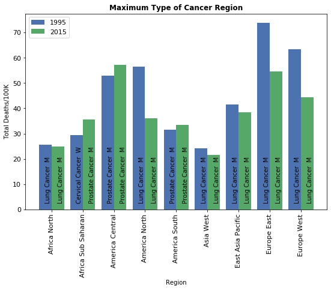

```python
#It draws the result in a bar plot.
#In the x-axis we set nine regions in which we have divided the world.
#In the y-axis we can see the mean of the number of deaths for 100K people for the max cause of deaths.
#The results for the two years are showed in the same plot.
plt.subplots(figsize=(9, 6))
x = [0, 1, 2, 3, 4, 5, 6, 7, 8]
x1 = [0.4, 1.4, 2.4, 3.4, 4.4, 5.4, 6.4, 7.4, 8.4]
plt.bar(x, df7['Max Deaths 1995'], width=0.4)
plt.bar(x1, df7['Max Deaths 2015'], width=0.4)
plt.title('Maximum Type of Cancer Region', fontdict = {'fontsize': 12, 'fontweight': 'bold'})
plt.xlabel('Region')
plt.ylabel('Total Deaths/100K')
plt.xticks(fontsize=11, rotation=90);
plt.yticks(fontsize=11)
#We add the name of the cause of cancer on each bar.
for i, v in enumerate(df7.values):
    plt.text(i, 3, v[2], rotation=90, fontsize=10)

for i, v in enumerate(df7.values):
    plt.text(i+0.4, 3, v[4], rotation=90, fontsize=10)
plt.xticks(np.arange(9)+0.2, df7['Nine Regions'])
plt.legend(['1995','2015'],loc=2, fontsize = 11);
```

We can see here that lung cancer in men is the most frequent cause of death cancer in almost all the regions, except in South America, Central America and Subsaharian Africa. In this case, in 1995 is where the cervical cancer was predominant.

- To be more accurate we are going to study the correlation between each cancer type and the HDI. It seems obvious that some of the types tend to be more usual in more developed areas, while others increment its prevalence with the lowest developing indexes.

|  | Correlation 1995 | Correlation 2015 |
| --- | --- | --- |
| Colonandrectum Cancer Deaths M | 0.623 | 0.566 |
| Liver Cancer Deaths M | -0.373 | -0.301 |
| Lung Cancer Deaths M | 0.605 | 0.533 |
| Prostate Cancer Deaths M | 0.127 | -0.153 |
| Stomach Cancer Deaths M | 0.118 | -0.081 |
| Breast Cancer Deaths W | 0.370 | 0.045 |
| Cervical Cancer Deaths W | -0.699 | -0.744 |
| Colonandrectum Cancer Deaths W | 0.534 | 0.401 |
| Liver Cancer Deaths W | -0.464 | -0.311 |
| Lung Cancer Deaths W | 0.527 | 0.556 |
| Stomach Cancer Deaths W | -0.128 | -0.348 |
| Total Cancer Women Death | -0.132 | -0.301 |
| Total Cancer Men Death | 0.462 | 0.172 |

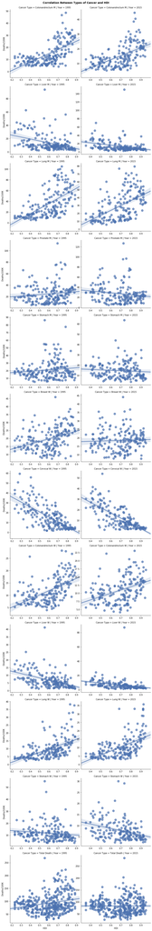

```python
#It plots the correlation between the HDI and the number of cancer deaths by cause.
#The result is showed in a matrix of graphs where the columns are identified  by year (1995 and 205)
#and the rows are indetified by the Cancer Type.
df9 = df_health3.query('year in ["1995", "2015"]')
df9.rename(columns=lambda x: x.strip().title().replace("_", " "), inplace=True)
g = sns.lmplot(x = 'Hdi',
           y = 'Cancer Deaths',
           data = df9,
           col = 'Year',
           row = 'Cancer Type',
           palette="Set1",
           fit_reg=True,
           markers='o',
           sharex=False,
           sharey=False,
           scatter = True,
           scatter_kws={"marker": "D", "s": 100, 'alpha': 0.7});

g.set_axis_labels("HDI", "Deaths/100K")
g.fig.suptitle("Correlation Between Types of Cancer and HDI",fontsize=12, fontweight='bold', y=1.003)
g.fig.subplots_adjust(wspace=.02);

#It prints a table with the numerical result of the correlation.
df_1995 = df_health2[df_health2['year'] == '1995']
df_2015 = df_health2[df_health2['year'] == '2015']
#We create two series with the correlation between hdi and each cause of cancer for each year.
corr_1995 = df_1995[df_1995.columns[4:]].apply(lambda x: x.corr(df_1995['hdi'])).round(3)
corr_2015 = df_2015[df_2015.columns[4:]].apply(lambda x: x.corr(df_2015['hdi'])).round(3)
#We concat the two series in one sigle dataframe. Rename de index so that the table looks better.
df_corr = pd.concat([corr_1995.rename('Correlation 1995'), corr_2015.rename('Correlation 2015')], axis=1)
df_corr.rename(index=lambda x: x.strip().title().replace("_", " "), inplace=True)
df_corr
```

An indirect finding of this analisys is that in the case of liver cancer, both for men and wemen, we have a clear outlier with much more cases of death than the rest of the world.

```python
df9[df9['Cancer Type'] == "Liver W"].sort_values(by = 'Cancer Deaths').set_index('Year').tail(4)
```

| Year | Country | Hdi | Nine Regions | Cancer Type | Cancer Deaths |
| --- | --- | --- | --- | --- | --- |
| 2015 | Gambia | 0.452 | africa_sub_saharan | Liver W | 24.4 |
| 1995 | Gambia | 0.351 | africa_sub_saharan | Liver W | 25.3 |
| 1995 | Mongolia | 0.554 | east_asia_pacific | Liver W | 41.2 |
| 2015 | Mongolia | 0.735 | east_asia_pacific | Liver W | 87.1 |

Moreover, if we sum all the total cancer causes, Mongolia seems to have a very high rate of deaths every 100 thousand people comparatively with the rest of the countries:

```python
df9.drop(columns = 'Hdi').query('Year == "2015"').groupby('Country').sum().round(2).sort_values(by = 'Cancer Deaths').tail(2)
```

| Country | Cancer Deaths |
| --- | --- |
| Zimbabwe | 606.06 |
| Mongolia | 875.66 |

## Conclusions

### Conclusion 1:

From this analisys we can conclude that those countries with a greater life expectancy and with better results in cancer treatments tend, in general, to priorize the public health investments over the private investments. Whereas those countries with a high percentage of private health spending ususally have poorer results, probably because the total spending is very low in most of this cases. Anyway it seems that the responsability of achieve the higher marks in terms of health care belongs to the public investments, at least for the majority of the countries with the best results.

The best rate between private and total spending seems to be between 20% and 30%.

### Conclusion 2:

On the other hand, Subsaharian Africa had a very low increment in the health costs by person, but they have experimented a big increment in the life expectancy. But they don't have as good results in terms of cancer healing percentage, which continue to be very low.

Anyway I have doubts about the cancer data collected in the Subsaharian Africa, they probably are incomplete and they don't reflect all the actual cases.

| nine_regions | Life Expectancy Inc | Total Cancer Heal Pc Inc | Total Health Spend Inc |
| --- | --- | --- | --- |
| Africa North | 3.28 | 9.65 | 128.72 |
| Africa Sub Saharan | 4.37 | 0.44 | 77.29 |
| America Central | 1.13 | 5.27 | 304.46 |
| America North | 2.90 | 8.26 | 2786.00 |
| America South | 3.20 | 8.66 | 298.87 |
| Asia West | 4.50 | 8.61 | 266.18 |
| East Asia Pacific | 3.68 | 7.30 | 410.52 |
| Europe East | 4.28 | 9.06 | 567.35 |
| Europe West | 3.59 | 10.63 | 2342.71 |

Finally we have seen that, until 70 years, to increase a year in the life expectancy costs around 100$ per person or less, but above the 70 years the costs suffer a considerably increment, up to 600$ or 700$ per person.

### Conclusion 3:

In this part we have found out that not all the types of cancer are so usual in all regions of the planet. In general, the lung cancer in men is the most frecuent type of cancer in almost all regions, but in Subsaharian Africa, Central America and South America, the prostate cancer seems to be the most frequent. We also have seen that, in the case os Subsaharian Africa, the cervical cancer was the most common in 1995.

There are also some types of cancer that have not almost correlation.

This can be due to the access to the cancer treatments and to the life expectancy, because some types of cancer are more usual at advanced ages.

I attach again the table with the correlation index between the hdi and each tipe of cancer:

|  | Correlation 1995 | Correlation 2015 |
| --- | --- | --- |
| Colonandrectum Cancer Deaths M | 0.623 | 0.566 |
| Liver Cancer Deaths M | -0.373 | -0.301 |
| Lung Cancer Deaths M | 0.605 | 0.533 |
| Prostate Cancer Deaths M | 0.127 | -0.153 |
| Stomach Cancer Deaths M | 0.118 | -0.081 |
| Breast Cancer Deaths W | 0.370 | 0.045 |
| Cervical Cancer Deaths W | -0.699 | -0.744 |
| Colonandrectum Cancer Deaths W | 0.534 | 0.401 |
| Liver Cancer Deaths W | -0.464 | -0.311 |
| Lung Cancer Deaths W | 0.527 | 0.556 |
| Stomach Cancer Deaths W | -0.128 | -0.348 |
| Total Cancer Women Death | -0.132 | -0.301 |
| Total Cancer Men Death | 0.462 | 0.172 |

And this is the table with the most usual type of cancer death in each region:

| Nine Regions | Max Deaths 1995 | Max Cancer Case 1995 | Max Deaths 2015 | Max Cancer Case 2015 |
| --- | --- | --- | --- | --- |
| Africa North | 25.69 | Lung Cancer M | 25.00 | Lung Cancer M |
| Africa Sub Saharan | 29.30 | Cervical Cancer W | 35.67 | Prostate Cancer M |
| America Central | 52.90 | Prostate Cancer M | 57.16 | Prostate Cancer M |
| America North | 56.40 | Lung Cancer M | 36.03 | Lung Cancer M |
| America South | 31.50 | Prostate Cancer M | 33.48 | Prostate Cancer M |
| Asia West | 24.30 | Lung Cancer M | 21.70 | Lung Cancer M |
| East Asia Pacific | 41.63 | Lung Cancer M | 38.36 | Lung Cancer M |
| Europe East | 73.73 | Lung Cancer M | 54.68 | Lung Cancer M |
| Europe West | 63.43 | Lung Cancer M | 44.31 | Lung Cancer M |